# Final.project

Samira Bechi

2023-11-24

# INTRODUCTION

[link for the Airbnb data](https://www.kaggle.com/datasets/PromptCloudHQ/airbnb-property-data-from-texas) Airbnb is an online platform that facilitates the booking and rental of lodging, primarily homes or apartments, on a short-term basis. Founded in 2008, Airbnb has grown into a global marketplace that connects people looking to rent their homes with travelers seeking unique and often more affordable accommodations than traditional hotels. The platform allows hosts to list their properties, providing details about the space, amenities, and pricing, while guests can browse listings and book accommodations for a specified period. I’ve heard many good things about this business but have not seen a market study. Today, I decided to work with this data (Airbnb property data from Texas from 2008 to 2017). This dataset includes the average night price, number of bedrooms, location, the year listed, and description, which aligns with my interest in studying the market. At the end of our analyses, we will be able to respond to multiple questions such as how many listings is there in Texas, how Airbnb has grown in Texas from 2008 to 2017, what city is the most popular with Airbnb; what is the average per night, per year, per bedroom; what number of the bedroom is the most popular? Through our analysis, we will find approaches to our findings. Our data will give a visualization and give people an idea of this business.

# LIBRARY USED

# UNFILTERED DATA

```
## Rows: 18,259
## Columns: 10
## $ X                      <int> 1, 2, 3, 4, 5, 6, 7, 8, 9, 10, 11, 12, 13, 14, …
## $ average_rate_per_night <chr> "$27", "$149", "$59", "$60", "$75", "$250", "$1…
## $ bedrooms_count         <chr> "2", "4", "1", "1", "2", "4", "3", "1", "3", "S…
## $ city                   <chr> "Humble", "San Antonio", "Houston", "Bryan", "F…
## $ date_of_listing        <chr> "May 2016", "November 2010", "January 2017", "F…
## $ description            <chr> "Welcome to stay in private room with queen bed…
## $ latitude               <dbl> 30.02014, 29.50307, 29.82935, 30.63730, 32.7471…
## $ longitude              <dbl> -95.29400, -98.44769, -95.08155, -96.33785, -97…
## $ title                  <chr> "2 Private rooms/bathroom 10min from IAH airpor…
## $ url                    <chr> "https://www.airbnb.com/rooms/18520444?location…
```

# FORMATING DATA

```
## Rows: 18,259
## Columns: 6
## $ X                      <int> 1, 2, 3, 4, 5, 6, 7, 8, 9, 10, 11, 12, 13, 14, …
## $ average_rate_per_night <dbl> 27, 149, 59, 60, 75, 250, 129, 25, 345, 72, 65,…
## $ bedrooms_count         <dbl> 2, 4, 1, 1, 2, 4, 3, 1, 3, 1, 1, 1, 2, 1, 2, 2,…
## $ city                   <chr> "Humble", "San Antonio", "Houston", "Bryan", "F…
## $ month                  <fct> May, November, January, February, February, Aug…
## $ year                   <fct> 2016, 2010, 2017, 2016, 2017, 2016, 2016, 2016,…
```

# DATA KEY TERMS

**average_rate_per_night** cost of the room per night **bedrooms_count** number of bedroom **city** location of the airbnb **date_of_listing** date when airbnb was available on platform ## 1- Total Airbnb from 2008 to 2017 From 2008 to 2017 exactly 18,259 were created in Texas. ## 2- Number of houses by year We are taking our formatted data to display the number of houses per year. This will help us determine what year had the most additional Airbnbs and if there was an increase or decrease in the number of Airbnbs added yearly.

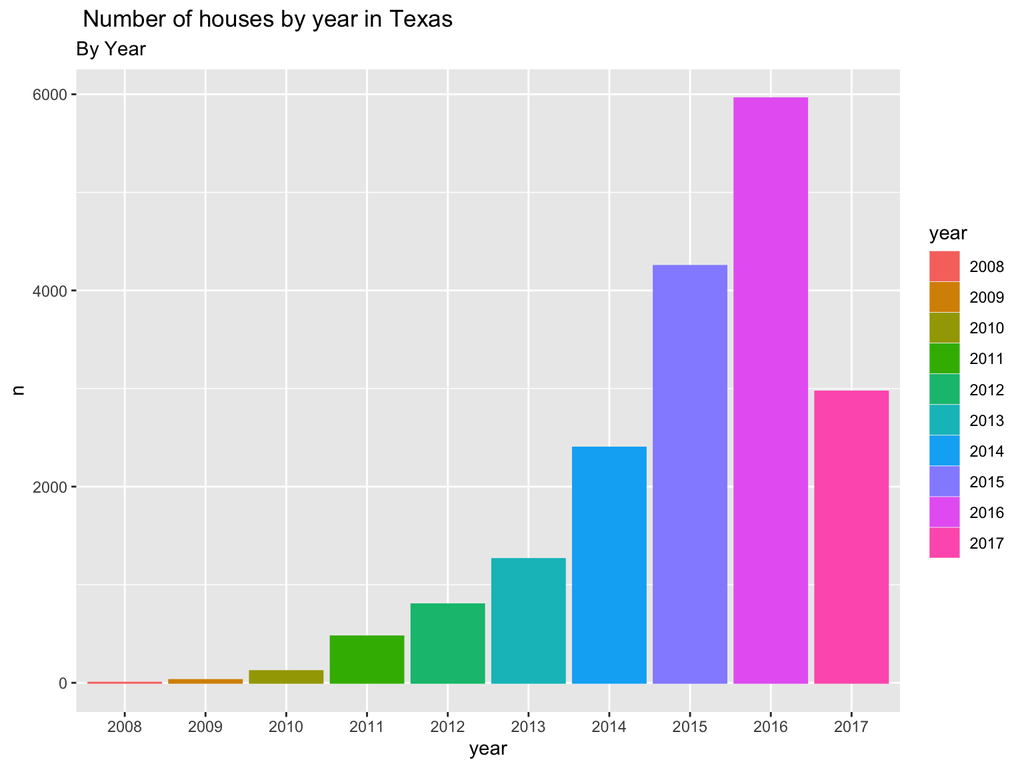

# 4- Top 10 city with most airbnb

| city | n |
| --- | --- |
| Houston | 1507 |
| Austin | 1484 |
| San Antonio | 1227 |
| Dallas | 1145 |
| Fort Worth | 999 |
| Corpus Christi | 643 |
| College Station | 480 |
| Irving | 403 |
| Bryan | 358 |
| New Braunfels | 306 |
| Galveston | 305 |
| McKinney | 286 |
| Arlington | 272 |
| Denton | 252 |
| Katy | 217 |
| South Padre Island | 195 |
| Port Aransas | 187 |
| Rockport | 184 |
| Horseshoe Bay | 168 |
| Richmond | 158 |
| Marble Falls | 154 |
| Conroe | 152 |
| Plano | 152 |
| League City | 138 |
| Canyon Lake | 134 |
| Wimberley | 132 |
| Lago Vista | 131 |
| Spicewood | 126 |
| Bandera | 124 |
| Spring | 121 |

[output cut: 475 more lines]

# 5- Average rate per night per month

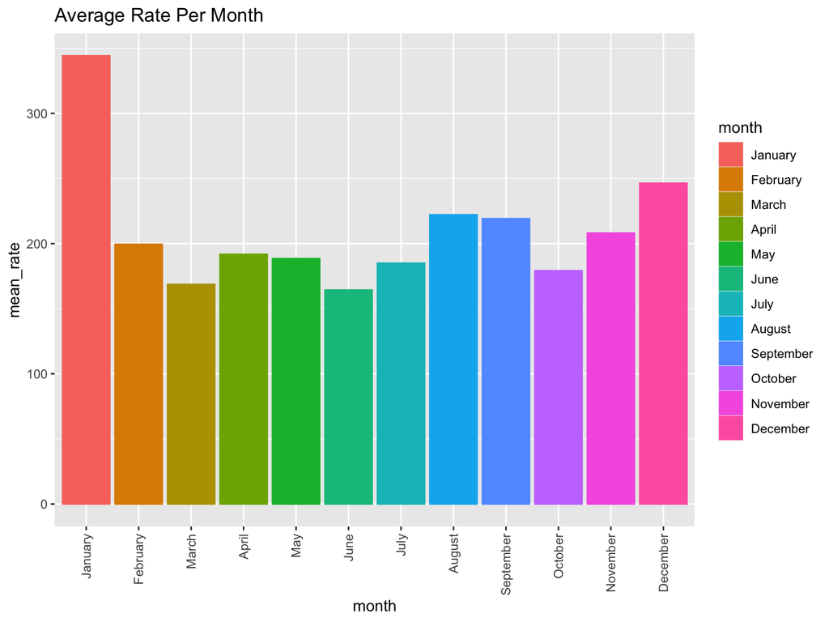

## 6- Average rate per night per year

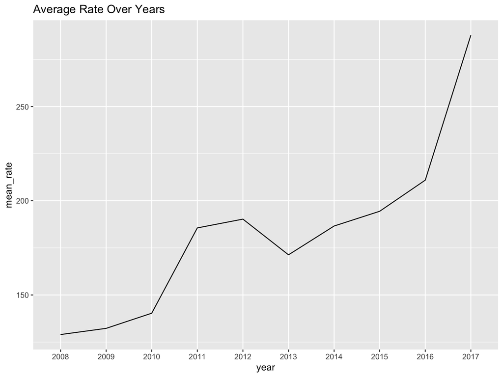

## 7- Number of bedrooms

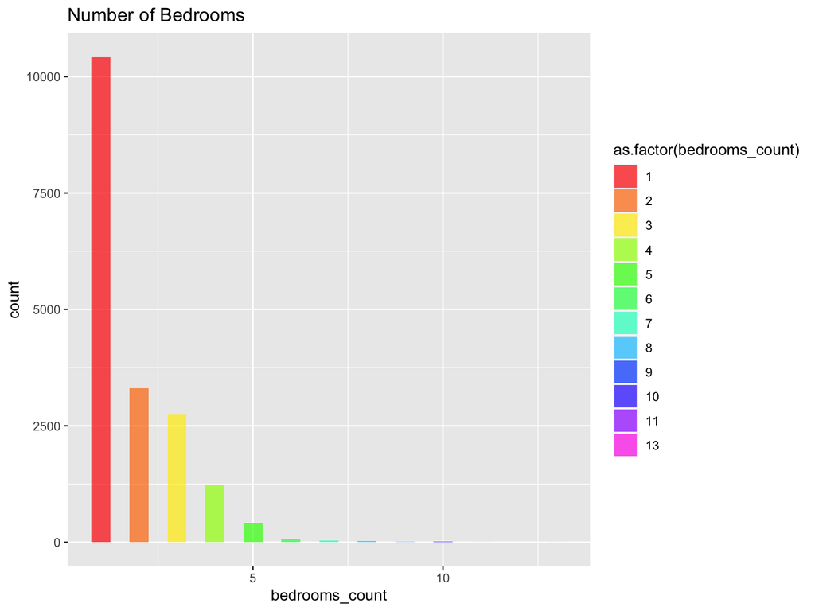

## 8-Average rate night per bedroom

```
## # A tibble: 13 × 2
##    bedrooms_count mean_rate
##             <dbl>     <dbl>
##  1              1      92.0
##  2              2     194.
##  3              3     334.
##  4              4     604.
##  5              5     944.
##  6              6    1166.
##  7              7    1172.
##  8              8    1468.
##  9              9    2900
## 10             10    2053.
## 11             11    4803
## 12             13    3049
## 13             NA      94.7
```

# Conclusion

From 2008 to 2017, 18259 were listed in Texas, but massive growth started around 2011. When we look at the top 10 cities with the most listings, we realize they are the big cities of Texas with many visitors, international airports, attractions… The average rate per night has considerably grown over the years. One bedroom is the most popular listing because it’s the cheapest average night. Overall, Airbnb is a trendy business in Texas, and the questions we answered should help investors direct themselves into this business.